# Practical Machine Learning Course Project

Duc Doan

2018/01/14

```r
knitr::opts_chunk$set(echo = TRUE)
options(warn = -1)
#options(width = 350)
```

## Problem Statement

The goal of this classification problem will be to use the data from accelerometers on the belt, forearm, arm, and dumbell of 6 participants asked to perform barbell lifts correctly and incorrectly in 5 different ways. Then, the classifier is built to categorize the activity of an user.

## Load the Datasets

Load the training dataset and testing dataset and save in the current working folder.

```r
options(warn = -1)
library(dplyr)
```

```r
download.file("https://d396qusza40orc.cloudfront.net/predmachlearn/pml-training.csv", "pml-training.csv", quiet = FALSE)
download.file("https://d396qusza40orc.cloudfront.net/predmachlearn/pml-testing.csv", "pml-testing.csv", quiet = FALSE)
train.set <- read.csv("./pml-training.csv", header = TRUE)
test.set <- read.csv("./pml-testing.csv", header = TRUE)
train.set <- tbl_df(train.set) # transform to new data frame with more information
test.set <- tbl_df(test.set) # transform to new data frame with more information
```

## Cleaning Data and Feature Selection

In this classification problem, we only use the features with full data. After checking the datasets, the following features are chosen for the classification problem.

```r
options(warn = -1)
# the training dataset
head(train.set)
```

```
## # A tibble: 6 x 160
##       X user_… raw_ti… raw_ti… cvtd_… new_w… num_… roll… pitc… yaw_… tota…
##   <int> <fctr>   <int>   <int> <fctr> <fctr> <int> <dbl> <dbl> <dbl> <int>
## 1     1 carli…  1.32e⁹  788290 05/12… no        11  1.41  8.07 -94.4     3
## 2     2 carli…  1.32e⁹  808298 05/12… no        11  1.41  8.07 -94.4     3
## 3     3 carli…  1.32e⁹  820366 05/12… no        11  1.42  8.07 -94.4     3
## 4     4 carli…  1.32e⁹  120339 05/12… no        12  1.48  8.05 -94.4     3
## 5     5 carli…  1.32e⁹  196328 05/12… no        12  1.48  8.07 -94.4     3
## 6     6 carli…  1.32e⁹  304277 05/12… no        12  1.45  8.06 -94.4     3
## # ... with 149 more variables: kurtosis_roll_belt <fctr>,
## #   kurtosis_picth_belt <fctr>, kurtosis_yaw_belt <fctr>,
## #   skewness_roll_belt <fctr>, skewness_roll_belt.1 <fctr>,
## #   skewness_yaw_belt <fctr>, max_roll_belt <dbl>, max_picth_belt <int>,
## #   max_yaw_belt <fctr>, min_roll_belt <dbl>, min_pitch_belt <int>,
## #   min_yaw_belt <fctr>, amplitude_roll_belt <dbl>, amplitude_pitch_belt
## #   <int>, amplitude_yaw_belt <fctr>, var_total_accel_belt <dbl>,
## #   avg_roll_belt <dbl>, stddev_roll_belt <dbl>, var_roll_belt <dbl>,
## #   avg_pitch_belt <dbl>, stddev_pitch_belt <dbl>, var_pitch_belt <dbl>,
## #   avg_yaw_belt <dbl>, stddev_yaw_belt <dbl>, var_yaw_belt <dbl>,
## #   gyros_belt_x <dbl>, gyros_belt_y <dbl>, gyros_belt_z <dbl>,
## #   accel_belt_x <int>, accel_belt_y <int>, accel_belt_z <int>,
## #   magnet_belt_x <int>, magnet_belt_y <int>, magnet_belt_z <int>,
## #   roll_arm <dbl>, pitch_arm <dbl>, yaw_arm <dbl>, total_accel_arm <int>,
## #   var_accel_arm <dbl>, avg_roll_arm <dbl>, stddev_roll_arm <dbl>,
## #   var_roll_arm <dbl>, avg_pitch_arm <dbl>, stddev_pitch_arm <dbl>,
## #   var_pitch_arm <dbl>, avg_yaw_arm <dbl>, stddev_yaw_arm <dbl>,
## #   var_yaw_arm <dbl>, gyros_arm_x <dbl>, gyros_arm_y <dbl>, gyros_arm_z
## #   <dbl>, accel_arm_x <int>, accel_arm_y <int>, accel_arm_z <int>,
## #   magnet_arm_x <int>, magnet_arm_y <int>, magnet_arm_z <int>,
## #   kurtosis_roll_arm <fctr>, kurtosis_picth_arm <fctr>, kurtosis_yaw_arm
## #   <fctr>, skewness_roll_arm <fctr>, skewness_pitch_arm <fctr>,
## #   skewness_yaw_arm <fctr>, max_roll_arm <dbl>, max_picth_arm <dbl>,
## #   max_yaw_arm <int>, min_roll_arm <dbl>, min_pitch_arm <dbl>,
## #   min_yaw_arm <int>, amplitude_roll_arm <dbl>, amplitude_pitch_arm
## #   <dbl>, amplitude_yaw_arm <int>, roll_dumbbell <dbl>, pitch_dumbbell
## #   <dbl>, yaw_dumbbell <dbl>, kurtosis_roll_dumbbell <fctr>,
## #   kurtosis_picth_dumbbell <fctr>, kurtosis_yaw_dumbbell <fctr>,
## #   skewness_roll_dumbbell <fctr>, skewness_pitch_dumbbell <fctr>,
## #   skewness_yaw_dumbbell <fctr>, max_roll_dumbbell <dbl>,
## #   max_picth_dumbbell <dbl>, max_yaw_dumbbell <fctr>, min_roll_dumbbell
## #   <dbl>, min_pitch_dumbbell <dbl>, min_yaw_dumbbell <fctr>,
## #   amplitude_roll_dumbbell <dbl>, amplitude_pitch_dumbbell <dbl>,
## #   amplitude_yaw_dumbbell <fctr>, total_accel_dumbbell <int>,
## #   var_accel_dumbbell <dbl>, avg_roll_dumbbell <dbl>,
## #   stddev_roll_dumbbell <dbl>, var_roll_dumbbell <dbl>,
## #   avg_pitch_dumbbell <dbl>, stddev_pitch_dumbbell <dbl>,
## #   var_pitch_dumbbell <dbl>, avg_yaw_dumbbell <dbl>, stddev_yaw_dumbbell
## #   <dbl>, ...
```

```r
# the testing dataset
head(test.set)
```

```
## # A tibble: 6 x 160
##       X user_… raw_tim… raw_tim… cvtd… new_… num_… roll_be… pitch… yaw_be…
##   <int> <fctr>    <int>    <int> <fct> <fct> <int>    <dbl>  <dbl>   <dbl>
## 1     1 pedro    1.32e⁹   868349 05/1… no       74  123      27.0  -  4.75
## 2     2 jeremy   1.32e⁹   778725 30/1… no      431    1.02    4.87 - 88.9
## 3     3 jeremy   1.32e⁹   342967 30/1… no      439    0.870   1.82 - 88.5
## 4     4 adelmo   1.32e⁹   560311 02/1… no      194  125     -41.6   162
## 5     5 eurico   1.32e⁹   814776 28/1… no      235    1.35    3.33 - 88.6
## 6     6 jeremy   1.32e⁹   510661 30/1… no      504 -  5.92    1.59 - 87.7
## # ... with 150 more variables: total_accel_belt <int>, kurtosis_roll_belt
## #   <lgl>, kurtosis_picth_belt <lgl>, kurtosis_yaw_belt <lgl>,
## #   skewness_roll_belt <lgl>, skewness_roll_belt.1 <lgl>,
## #   skewness_yaw_belt <lgl>, max_roll_belt <lgl>, max_picth_belt <lgl>,
## #   max_yaw_belt <lgl>, min_roll_belt <lgl>, min_pitch_belt <lgl>,
## #   min_yaw_belt <lgl>, amplitude_roll_belt <lgl>, amplitude_pitch_belt
## #   <lgl>, amplitude_yaw_belt <lgl>, var_total_accel_belt <lgl>,
## #   avg_roll_belt <lgl>, stddev_roll_belt <lgl>, var_roll_belt <lgl>,
## #   avg_pitch_belt <lgl>, stddev_pitch_belt <lgl>, var_pitch_belt <lgl>,
## #   avg_yaw_belt <lgl>, stddev_yaw_belt <lgl>, var_yaw_belt <lgl>,
## #   gyros_belt_x <dbl>, gyros_belt_y <dbl>, gyros_belt_z <dbl>,
## #   accel_belt_x <int>, accel_belt_y <int>, accel_belt_z <int>,
## #   magnet_belt_x <int>, magnet_belt_y <int>, magnet_belt_z <int>,
## #   roll_arm <dbl>, pitch_arm <dbl>, yaw_arm <dbl>, total_accel_arm <int>,
## #   var_accel_arm <lgl>, avg_roll_arm <lgl>, stddev_roll_arm <lgl>,
## #   var_roll_arm <lgl>, avg_pitch_arm <lgl>, stddev_pitch_arm <lgl>,
## #   var_pitch_arm <lgl>, avg_yaw_arm <lgl>, stddev_yaw_arm <lgl>,
## #   var_yaw_arm <lgl>, gyros_arm_x <dbl>, gyros_arm_y <dbl>, gyros_arm_z
## #   <dbl>, accel_arm_x <int>, accel_arm_y <int>, accel_arm_z <int>,
## #   magnet_arm_x <int>, magnet_arm_y <int>, magnet_arm_z <int>,
## #   kurtosis_roll_arm <lgl>, kurtosis_picth_arm <lgl>, kurtosis_yaw_arm
## #   <lgl>, skewness_roll_arm <lgl>, skewness_pitch_arm <lgl>,
## #   skewness_yaw_arm <lgl>, max_roll_arm <lgl>, max_picth_arm <lgl>,
## #   max_yaw_arm <lgl>, min_roll_arm <lgl>, min_pitch_arm <lgl>,
## #   min_yaw_arm <lgl>, amplitude_roll_arm <lgl>, amplitude_pitch_arm
## #   <lgl>, amplitude_yaw_arm <lgl>, roll_dumbbell <dbl>, pitch_dumbbell
## #   <dbl>, yaw_dumbbell <dbl>, kurtosis_roll_dumbbell <lgl>,
## #   kurtosis_picth_dumbbell <lgl>, kurtosis_yaw_dumbbell <lgl>,
## #   skewness_roll_dumbbell <lgl>, skewness_pitch_dumbbell <lgl>,
## #   skewness_yaw_dumbbell <lgl>, max_roll_dumbbell <lgl>,
## #   max_picth_dumbbell <lgl>, max_yaw_dumbbell <lgl>, min_roll_dumbbell
## #   <lgl>, min_pitch_dumbbell <lgl>, min_yaw_dumbbell <lgl>,
## #   amplitude_roll_dumbbell <lgl>, amplitude_pitch_dumbbell <lgl>,
## #   amplitude_yaw_dumbbell <lgl>, total_accel_dumbbell <int>,
## #   var_accel_dumbbell <lgl>, avg_roll_dumbbell <lgl>,
## #   stddev_roll_dumbbell <lgl>, var_roll_dumbbell <lgl>,
## #   avg_pitch_dumbbell <lgl>, stddev_pitch_dumbbell <lgl>,
## #   var_pitch_dumbbell <lgl>, avg_yaw_dumbbell <lgl>, ...
```

```r
# find column names, where their type is factor, and there is no NA data
factor.all.column.names <- names(train.set)[sapply(train.set, is.factor)]
factor.non.na.num <- apply(!is.na(train.set[, factor.all.column.names]), 2, sum)
factor.column.names <- names(factor.non.na.num[factor.non.na.num > nrow(train.set)/5])
length(factor.column.names)
```

```
## [1] 37
```

```r
# remove the following factor columns
factor.non.used.column.names <- c("cvtd_timestamp", "new_window", "kurtosis_roll_belt", "kurtosis_picth_belt",
                                  "kurtosis_yaw_belt", "skewness_roll_belt", "skewness_roll_belt.1", "skewness_yaw_belt",
                                  "max_yaw_belt", "min_yaw_belt", "amplitude_yaw_belt", "kurtosis_roll_arm",
                                  "kurtosis_picth_arm", "kurtosis_yaw_arm", "skewness_roll_arm", "skewness_pitch_arm",
                                  "skewness_yaw_arm", "kurtosis_roll_dumbbell", "kurtosis_picth_dumbbell", "kurtosis_yaw_dumbbell",
                                  "skewness_roll_dumbbell", "skewness_pitch_dumbbell", "skewness_yaw_dumbbell", "max_yaw_dumbbell",
                                  "min_yaw_dumbbell", "amplitude_yaw_dumbbell", "kurtosis_roll_forearm", "kurtosis_picth_forearm",
                                  "kurtosis_yaw_forearm", "skewness_roll_forearm", "skewness_pitch_forearm", "skewness_yaw_forearm",
                                  "max_yaw_forearm", "min_yaw_forearm", "amplitude_yaw_forearm")
# factor columns used
factor.used.column.names <- factor.column.names[!factor.column.names %in% factor.non.used.column.names]
# find column names, where their type is numeric, and there is no NA data
numeric.all.column.names <- names(train.set)[sapply(train.set, is.numeric)]
numeric.non.na.num <- apply(!is.na(train.set[, numeric.all.column.names]), 2, sum)
numeric.column.names <- names(numeric.non.na.num[numeric.non.na.num > nrow(train.set)/5])
length(numeric.column.names)
```

```
## [1] 56
```

```r
# remove the following numeric columns
numeric.non.used.column.names <- c("X", "raw_timestamp_part_1", "raw_timestamp_part_2", "num_window")
# numeric columns used
numeric.used.column.names <- numeric.column.names[!numeric.column.names %in% numeric.non.used.column.names]
```

## Create Cleaned Datasets for Training and Testing

```r
options(warn = -1)
# training dataset cleaned
train.set.df <- train.set %>% select(c(factor.used.column.names, numeric.used.column.names))
train.label.df <- train.set.df %>% select(c("classe"))
train.set.df <- train.set.df %>% select(names(train.set.df)[!names(train.set.df) %in% c("classe")])
train.set.df$classe <- train.label.df$classe
# testing dataset cleaned
used.column.names <- c(factor.used.column.names, numeric.used.column.names)
test.set.df <- test.set %>% select(used.column.names[used.column.names %in% names(test.set)])
if (sum(names(test.set.df) %in% c("classe")) > 0) {
    test.label.df <- test.set.df %>% select(c("classe"))
    test.set.df <- test.set.df %>% select(names(test.set.df)[!names(test.set.df) %in% c("classe")])
    test.set.df$classe <- test.label.df$classe
}
# Create the new datasets for training and testing for convenience
write.csv(train.set.df, "trainingset.csv", row.names = FALSE)
write.csv(test.set.df, "testingset.csv", row.names = FALSE)
head(train.set.df)
```

```
## # A tibble: 6 x 54
##   user_… roll_… pitch… yaw_… tota… gyros… gyros… gyros_… acce… acce… acce…
##   <fctr>  <dbl>  <dbl> <dbl> <int>  <dbl>  <dbl>   <dbl> <int> <int> <int>
## 1 carli…   1.41   8.07 -94.4     3 0      0      -0.0200   -21     4    22
## 2 carli…   1.41   8.07 -94.4     3 0.0200 0      -0.0200   -22     4    22
## 3 carli…   1.42   8.07 -94.4     3 0      0      -0.0200   -20     5    23
## 4 carli…   1.48   8.05 -94.4     3 0.0200 0      -0.0300   -22     3    21
## 5 carli…   1.48   8.07 -94.4     3 0.0200 0.0200 -0.0200   -21     2    24
## 6 carli…   1.45   8.06 -94.4     3 0.0200 0      -0.0200   -21     4    21
## # ... with 43 more variables: magnet_belt_x <int>, magnet_belt_y <int>,
## #   magnet_belt_z <int>, roll_arm <dbl>, pitch_arm <dbl>, yaw_arm <dbl>,
## #   total_accel_arm <int>, gyros_arm_x <dbl>, gyros_arm_y <dbl>,
## #   gyros_arm_z <dbl>, accel_arm_x <int>, accel_arm_y <int>, accel_arm_z
## #   <int>, magnet_arm_x <int>, magnet_arm_y <int>, magnet_arm_z <int>,
## #   roll_dumbbell <dbl>, pitch_dumbbell <dbl>, yaw_dumbbell <dbl>,
## #   total_accel_dumbbell <int>, gyros_dumbbell_x <dbl>, gyros_dumbbell_y
## #   <dbl>, gyros_dumbbell_z <dbl>, accel_dumbbell_x <int>,
## #   accel_dumbbell_y <int>, accel_dumbbell_z <int>, magnet_dumbbell_x
## #   <int>, magnet_dumbbell_y <int>, magnet_dumbbell_z <dbl>, roll_forearm
## #   <dbl>, pitch_forearm <dbl>, yaw_forearm <dbl>, total_accel_forearm
## #   <int>, gyros_forearm_x <dbl>, gyros_forearm_y <dbl>, gyros_forearm_z
## #   <dbl>, accel_forearm_x <int>, accel_forearm_y <int>, accel_forearm_z
## #   <int>, magnet_forearm_x <int>, magnet_forearm_y <dbl>,
## #   magnet_forearm_z <dbl>, classe <fctr>
```

```r
head(test.set.df)
```

```
## # A tibble: 6 x 53
##   user_… roll_be… pitch… yaw_be… tota… gyros_… gyros_… gyros_… acce… acce…
##   <fctr>    <dbl>  <dbl>   <dbl> <int>   <dbl>   <dbl>   <dbl> <int> <int>
## 1 pedro   123      27.0  -  4.75    20 -0.500  -0.0200 -0.460    -38    69
## 2 jeremy    1.02    4.87 - 88.9      4 -0.0600 -0.0200 -0.0700   -13    11
## 3 jeremy    0.870   1.82 - 88.5      5  0.0500  0.0200  0.0300     1   - 1
## 4 adelmo  125     -41.6   162       17  0.110   0.110  -0.160     46    45
## 5 eurico    1.35    3.33 - 88.6      3  0.0300  0.0200  0        - 8     4
## 6 jeremy -  5.92    1.59 - 87.7      4  0.100   0.0500 -0.130    -11   -16
## # ... with 43 more variables: accel_belt_z <int>, magnet_belt_x <int>,
## #   magnet_belt_y <int>, magnet_belt_z <int>, roll_arm <dbl>, pitch_arm
## #   <dbl>, yaw_arm <dbl>, total_accel_arm <int>, gyros_arm_x <dbl>,
## #   gyros_arm_y <dbl>, gyros_arm_z <dbl>, accel_arm_x <int>, accel_arm_y
## #   <int>, accel_arm_z <int>, magnet_arm_x <int>, magnet_arm_y <int>,
## #   magnet_arm_z <int>, roll_dumbbell <dbl>, pitch_dumbbell <dbl>,
## #   yaw_dumbbell <dbl>, total_accel_dumbbell <int>, gyros_dumbbell_x
## #   <dbl>, gyros_dumbbell_y <dbl>, gyros_dumbbell_z <dbl>,
## #   accel_dumbbell_x <int>, accel_dumbbell_y <int>, accel_dumbbell_z
## #   <int>, magnet_dumbbell_x <int>, magnet_dumbbell_y <int>,
## #   magnet_dumbbell_z <int>, roll_forearm <dbl>, pitch_forearm <dbl>,
## #   yaw_forearm <dbl>, total_accel_forearm <int>, gyros_forearm_x <dbl>,
## #   gyros_forearm_y <dbl>, gyros_forearm_z <dbl>, accel_forearm_x <int>,
## #   accel_forearm_y <int>, accel_forearm_z <int>, magnet_forearm_x <int>,
## #   magnet_forearm_y <int>, magnet_forearm_z <int>
```

## Training Dataset and Testing Dataset: Feature Transformation

Since only the first feature in the datasets , i.e. user, is factor type feature. For using XGBOOST, all of the features should be numeric type. Therefore, one-hot-coding is used to transform the feature user to numeric type.

```r
options(warn = -1)
library(dplyr)
library(caret)
library(xgboost)
# create the one hot encoder
oneHotEncoder <- function(x, levels) { return(ifelse ((x == levels) == TRUE, 1, 0)) }
# function to transform the factor features to numeric ones
featureOneHotEncoder <- function(df, factorFeatureColumns) {
    newdf <- df %>% select(-factorFeatureColumns)
    for (i in 1:length(factorFeatureColumns)) {
        iFactorFeatureColumn <- factorFeatureColumns[i] # get the factor feature column i
        df[, iFactorFeatureColumn] <- as.factor(df[, iFactorFeatureColumn]) # confirm the factor type
        iLevels <- unique(df[, iFactorFeatureColumn]) # get all levels of the factor feature column
        iNumLevels <- length(iLevels) # the number of levels
        idf <- data.frame(t(apply(data.frame(df[, iFactorFeatureColumn]), 1, oneHotEncoder, iLevels))) # one hot encoder
        iColumnName <- names(df)[iFactorFeatureColumn] # the column name of the factor feature column i
        # create column names for "idf"
        idfNames <- character(length = iNumLevels)
        for (j in 1:iNumLevels) {
            idfNames[j] <- paste(paste(iColumnName, "new_column", sep = "_"), sprintf("%d", j), sep = "_")
        }
        names(idf) <- idfNames
        newdf <- cbind(newdf, idf)
    }
    return(newdf)
}
# training dataset
encoded.train.set.df <- featureOneHotEncoder(as.data.frame(train.set.df), 1)
# testing dataset
encoded.test.set.df <- featureOneHotEncoder(as.data.frame(test.set.df), 1)
# correlation matrix
correlation.matrix <- cor(encoded.train.set.df[, !names(encoded.train.set.df) %in% c("classe")])
cut.off <- 0.9
high.correlated.features <- findCorrelation(correlation.matrix, cutoff = cut.off)
print(names(encoded.train.set.df)[high.correlated.features])
```

```
## [1] "accel_belt_z"           "roll_belt"
## [3] "accel_belt_y"           "user_name_new_column_2"
## [5] "accel_belt_x"           "user_name_new_column_1"
## [7] "gyros_dumbbell_x"       "gyros_dumbbell_z"
## [9] "gyros_arm_x"
```

```r
# Only use the low correlated features
correlation.matrix[upper.tri(correlation.matrix)] <- 0.0
diag(correlation.matrix) <- 0.0
new.train.set.df <- encoded.train.set.df %>% select(names(encoded.train.set.df)[apply(correlation.matrix, 2, function(x) any(x < cut.off))]) %>%
    mutate(classe = encoded.train.set.df$classe)
new.test.set.df <- encoded.test.set.df %>% select(names(encoded.test.set.df)[apply(correlation.matrix, 2, function(x) any(x < cut.off))])
# features used for classification problem
names(new.train.set.df)
```

```
##  [1] "roll_belt"              "pitch_belt"
##  [3] "yaw_belt"               "total_accel_belt"
##  [5] "gyros_belt_x"           "gyros_belt_y"
##  [7] "gyros_belt_z"           "accel_belt_x"
##  [9] "accel_belt_y"           "accel_belt_z"
## [11] "magnet_belt_x"          "magnet_belt_y"
## [13] "magnet_belt_z"          "roll_arm"
## [15] "pitch_arm"              "yaw_arm"
## [17] "total_accel_arm"        "gyros_arm_x"
## [19] "gyros_arm_y"            "gyros_arm_z"
## [21] "accel_arm_x"            "accel_arm_y"
## [23] "accel_arm_z"            "magnet_arm_x"
## [25] "magnet_arm_y"           "magnet_arm_z"
## [27] "roll_dumbbell"          "pitch_dumbbell"
## [29] "yaw_dumbbell"           "total_accel_dumbbell"
## [31] "gyros_dumbbell_x"       "gyros_dumbbell_y"
## [33] "gyros_dumbbell_z"       "accel_dumbbell_x"
## [35] "accel_dumbbell_y"       "accel_dumbbell_z"
## [37] "magnet_dumbbell_x"      "magnet_dumbbell_y"
## [39] "magnet_dumbbell_z"      "roll_forearm"
## [41] "pitch_forearm"          "yaw_forearm"
## [43] "total_accel_forearm"    "gyros_forearm_x"
## [45] "gyros_forearm_y"        "gyros_forearm_z"
## [47] "accel_forearm_x"        "accel_forearm_y"
## [49] "accel_forearm_z"        "magnet_forearm_x"
## [51] "magnet_forearm_y"       "magnet_forearm_z"
## [53] "classe"                 "user_name_new_column_1"
## [55] "user_name_new_column_2" "user_name_new_column_3"
## [57] "user_name_new_column_4" "user_name_new_column_5"
## [59] "user_name_new_column_6"
```

## Building Model using XGBOOST algorithm

XGBOOST algorithm will be used to build a model based the training dataset. The training dataset will be divided into two new dataset: (1) Training dataset for building model, and (2) Validating dataset for estimating model accuracy.

For building a model, we use k-fold cross validation method to check the default parameter configuration of XGBOOST. A confusion matrix is shown for evaluating the model accuracy.

```r
options(warn = -1)
library(nnet)
library(caret)
# label column must be categorical type (factor type)
new.train.set.df[, "classe"] <- as.factor(new.train.set.df[, "classe"])
# divide the the dataset into training data and validating data
set.seed(12345)
train <- sample(nrow(new.train.set.df), 0.99 * nrow(new.train.set.df))
df.train <- new.train.set.df[train, ]
df.valid <- new.train.set.df[-train, ]
# initialize seed
set.seed(12345)
# number of classes in dataset
nClasses <- length(unique(df.train[, "classe"]))
# label of output is factor
label.level <- unique(df.train[, "classe"])
# convert to number
value.level <- seq.int(0, nClasses - 1, 1)
# define a function to convert level.factor to value.level
label2value <- function(x, labelLevel, valueLevel) { return(valueLevel[labelLevel == x])}
# training variables and label
train.variables <- as.matrix(df.train[, !names(df.train) %in% c("classe")])
train.label.level <- df.train[, "classe"]
train.value.level <- apply(as.matrix(train.label.level), 1, label2value, label.level, value.level)
train.matrix <- xgb.DMatrix(data = train.variables, label = train.value.level)
# validating variables and label
valid.variables <- as.matrix(df.valid[, !names(df.valid) %in% c("classe")])
valid.label.level <- df.valid[, "classe"]
valid.value.level <- apply(as.matrix(valid.label.level), 1, label2value, label.level, value.level)
valid.matrix <- xgb.DMatrix(data = valid.variables, label = valid.value.level)
# testing variables and label
df.test <- new.test.set.df
df.test[, (ncol(df.test) + 1)] <- as.factor(df.train[1:nrow(df.test), "classe"])
names(df.test)[ncol(df.test)] <- "classe"
test.variables <- as.matrix(df.test[, !names(df.test) %in% c("classe")])
test.label.level <- df.test[, "classe"]
test.value.level <- apply(as.matrix(test.label.level), 1, label2value, label.level, value.level)
test.matrix <- xgb.DMatrix(data = test.variables, label = test.value.level)
# parameters for XGBoost
xgb.params <- list("objective" = "multi:softprob",
                   "eval_metric" = "mlogloss",
                   "num_class" = nClasses)
cv.nrounds <- 50 # number of XGBoost rounds
cv.nfold <- 10 # k-fold
# Fit cv.nfold * cv.nround XGB models and save OOF predictions
cv.model <- xgb.cv(params = xgb.params,
                   data = train.matrix,
                   nrounds = cv.nrounds,
                   nfold = cv.nfold,
                   verbose = FALSE,
                   prediction = TRUE)
# define a function to convert back value.level to level.factor
value2label <- function(x, valueLevel, labelLevel) { return(labelLevel[valueLevel == x])}
OOF.xgb <- data.frame(cv.model$pred) %>%
    mutate(max.prob = max.col(., ties.method = "last"), label = train.label.level)
OOF.xgb$predicted <- apply(data.frame(OOF.xgb$max.prob - 1), 1, value2label, value.level, as.character(label.level))
OOF.xgb$max.prob <- NULL
# confusion matrix in cross validation
confusionMatrix(factor(OOF.xgb$label), factor(OOF.xgb$predicted), mode = "everything")
```

```
## Confusion Matrix and Statistics
##
##           Reference
## Prediction    A    B    C    D    E
##          A 5509    4    4    0    2
##          B    9 3744   11    0    0
##          C    0   11 3360   16    0
##          D    0    0   22 3164    3
##          E    0    1    2    4 3559
##
## Overall Statistics
##
##                Accuracy : 0.9954
##                  95% CI : (0.9944, 0.9963)
##     No Information Rate : 0.2841
##     P-Value [Acc > NIR] : < 2.2e-16
##
##                   Kappa : 0.9942
##  Mcnemar's Test P-Value : NA
##
## Statistics by Class:
##
##                      Class: A Class: B Class: C Class: D Class: E
## Sensitivity            0.9984   0.9957   0.9885   0.9937   0.9986
## Specificity            0.9993   0.9987   0.9983   0.9985   0.9996
## Pos Pred Value         0.9982   0.9947   0.9920   0.9922   0.9980
## Neg Pred Value         0.9994   0.9990   0.9976   0.9988   0.9997
## Precision              0.9982   0.9947   0.9920   0.9922   0.9980
## Recall                 0.9984   0.9957   0.9885   0.9937   0.9986
## F1                     0.9983   0.9952   0.9903   0.9929   0.9983
## Prevalence             0.2841   0.1936   0.1750   0.1639   0.1835
## Detection Rate         0.2836   0.1927   0.1730   0.1629   0.1832
## Detection Prevalence   0.2841   0.1938   0.1744   0.1642   0.1836
## Balanced Accuracy      0.9988   0.9972   0.9934   0.9961   0.9991
```

As shown in confusion matrix, since the accuracy of model is very high, we can use the default parameter configuration of XGBOOST for building the prediction model.

```r
options(warn = -1)
library(nnet)
library(caret)
nrounds <- 50
# Fit cv.nfold * cv.nround XGB models and save OOF predictions
fit.xgb <- xgb.train(params = xgb.params, data = train.matrix, nrounds = nrounds)
# calculate training prediction and validating prediction
train.xgb.value.vector <- predict(fit.xgb, newdata = train.matrix)
valid.xgb.value.vector <- predict(fit.xgb, newdata = valid.matrix)
test.xgb.value.vector <- predict(fit.xgb, newdata = test.matrix)
# convert back to value level in matrix
train.xgb.value <- matrix(train.xgb.value.vector, nrow = nClasses, ncol = nrow(train.variables)) %>%
    t() %>% data.frame()
valid.xgb.value <- matrix(valid.xgb.value.vector, nrow = nClasses, ncol = nrow(valid.variables)) %>%
    t() %>% data.frame()
test.xgb.value <- matrix(test.xgb.value.vector, nrow = nClasses, ncol = nrow(test.variables)) %>%
    t() %>% data.frame()
# convert back to label level
train.xgb <- apply(data.frame(apply(train.xgb.value, 1, which.is.max) - 1),
                   1, value2label, value.level, label.level)
valid.xgb <- apply(data.frame(apply(valid.xgb.value, 1, which.is.max) - 1),
                   1, value2label, value.level, label.level)
test.xgb <- apply(data.frame(apply(test.xgb.value, 1, which.is.max) - 1),
                  1, value2label, value.level, label.level)
# confusion matrix with validation data
confusionMatrix(valid.label.level, valid.xgb, mode = "everything")
```

```
## Confusion Matrix and Statistics
##
##           Reference
## Prediction  A  B  C  D  E
##          A 61  0  0  0  0
##          B  0 33  0  0  0
##          C  0  0 35  0  0
##          D  0  0  0 27  0
##          E  0  0  0  0 41
##
## Overall Statistics
##
##                Accuracy : 1
##                  95% CI : (0.9814, 1)
##     No Information Rate : 0.3096
##     P-Value [Acc > NIR] : < 2.2e-16
##
##                   Kappa : 1
##  Mcnemar's Test P-Value : NA
##
## Statistics by Class:
##
##                      Class: A Class: B Class: C Class: D Class: E
## Sensitivity            1.0000   1.0000   1.0000   1.0000   1.0000
## Specificity            1.0000   1.0000   1.0000   1.0000   1.0000
## Pos Pred Value         1.0000   1.0000   1.0000   1.0000   1.0000
## Neg Pred Value         1.0000   1.0000   1.0000   1.0000   1.0000
## Precision              1.0000   1.0000   1.0000   1.0000   1.0000
## Recall                 1.0000   1.0000   1.0000   1.0000   1.0000
## F1                     1.0000   1.0000   1.0000   1.0000   1.0000
## Prevalence             0.3096   0.1675   0.1777   0.1371   0.2081
## Detection Rate         0.3096   0.1675   0.1777   0.1371   0.2081
## Detection Prevalence   0.3096   0.1675   0.1777   0.1371   0.2081
## Balanced Accuracy      1.0000   1.0000   1.0000   1.0000   1.0000
```

```r
# prediction with test data
test.xgb
```

```
##  [1] B A B A A E D B A A B C B A E E A B B B
## Levels: A B C D E
```

As shown in confusion matrix with the validating dataset, the accuracy of prediction is also very high. Therefore, we expect high accuracy of prediction with the testing data is achieved.

## Feature Importance Analysis

In order to rank features in the dataset by their importance, we analyze their importance as follows:

```r
options(warn = -1)
library(caret)
library(xgboost)
# feature names
feature.names <- names(df.train)[!names(df.train) %in% c("classe")]
# important matrix
importance.matrix = xgb.importance(feature_names = feature.names, model = fit.xgb)
print(importance.matrix)
```

```
##                    Feature         Gain        Cover    Frequency
##  1:              roll_belt 0.1709030130 0.1034347330 0.0594131319
##  2:               yaw_belt 0.0919020049 0.0882920774 0.0794596165
##  3:          pitch_forearm 0.0798224771 0.0747578624 0.0450319582
##  4:      magnet_dumbbell_y 0.0660178076 0.0639996357 0.0411098199
##  5:           roll_forearm 0.0576409536 0.0501827728 0.0418361418
##  6:             pitch_belt 0.0567361162 0.0557026649 0.0496804184
##  7:      magnet_dumbbell_z 0.0559795752 0.0545642889 0.0490993608
##  8:          magnet_belt_z 0.0341994955 0.0325137203 0.0226612435
##  9:       accel_dumbbell_z 0.0266703368 0.0286512194 0.0228065078
## 10:       magnet_forearm_z 0.0248681498 0.0262759898 0.0262928530
## 11:       accel_dumbbell_y 0.0241375067 0.0195704184 0.0145264381
## 12:           gyros_belt_z 0.0225616422 0.0292071063 0.0184485764
## 13:        accel_forearm_x 0.0218323683 0.0181715673 0.0149622313
## 14:          roll_dumbbell 0.0198749881 0.0122178273 0.0177222545
```

[output cut: 41 more lines]

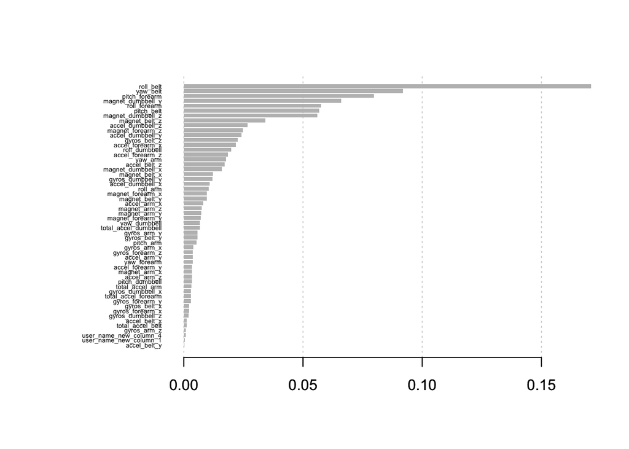

```r
# plot
feature.importance = xgb.plot.importance(importance.matrix)
```

```r
print(feature.importance)
```

```
##                    Feature         Gain        Cover    Frequency
##  1:              roll_belt 0.1709030130 0.1034347330 0.0594131319
##  2:               yaw_belt 0.0919020049 0.0882920774 0.0794596165
##  3:          pitch_forearm 0.0798224771 0.0747578624 0.0450319582
##  4:      magnet_dumbbell_y 0.0660178076 0.0639996357 0.0411098199
##  5:           roll_forearm 0.0576409536 0.0501827728 0.0418361418
##  6:             pitch_belt 0.0567361162 0.0557026649 0.0496804184
##  7:      magnet_dumbbell_z 0.0559795752 0.0545642889 0.0490993608
##  8:          magnet_belt_z 0.0341994955 0.0325137203 0.0226612435
##  9:       accel_dumbbell_z 0.0266703368 0.0286512194 0.0228065078
## 10:       magnet_forearm_z 0.0248681498 0.0262759898 0.0262928530
## 11:       accel_dumbbell_y 0.0241375067 0.0195704184 0.0145264381
## 12:           gyros_belt_z 0.0225616422 0.0292071063 0.0184485764
## 13:        accel_forearm_x 0.0218323683 0.0181715673 0.0149622313
## 14:          roll_dumbbell 0.0198749881 0.0122178273 0.0177222545
```

[output cut: 97 more lines]